*Remark.* For **Computational Part**, please complete your answer in the **RMarkdown** file and summit the generated PDF and RMD files.

## Computational Part

1. ([ISL] 4.11, *25 pt*) In this problem, you will develop a model to predict whether a given car gets high or low gas mileage based on the `Auto` data set. Write a data analysis report addressing the following problems.
   1. Create a binary variable, `mpg01`, that contains a 1 if `mpg` contains a value above its median, and a 0 if `mpg` contains a value below its median.

```r
library(ISLR)
data("Auto")
attach(Auto)
```

```r
library(tidyverse)
Auto <- Auto %>%
  mutate (mpg01 = factor(ifelse(mpg > median(mpg), 1, 0)))
median(Auto$mpg)
```

```
## [1] 22.75
```

2. Explore the data graphically in order to investigate the association between `mgp01` and the other features. Which of the other features seem most likely to be useful in predicting `mpg01`? Scatterplots and boxplots may be useful tools to answer this question. Describe your findings.

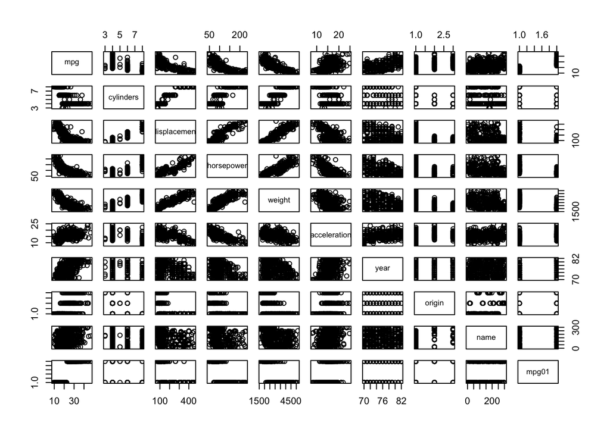

```r
#scatter plots
pairs(Auto)
```

From the scatter plot, we assume ‘cylinders’, ‘displacement’, ‘horsepower’ and ‘weight’ seem mostly likely to be useful in predicting `mpg01`.

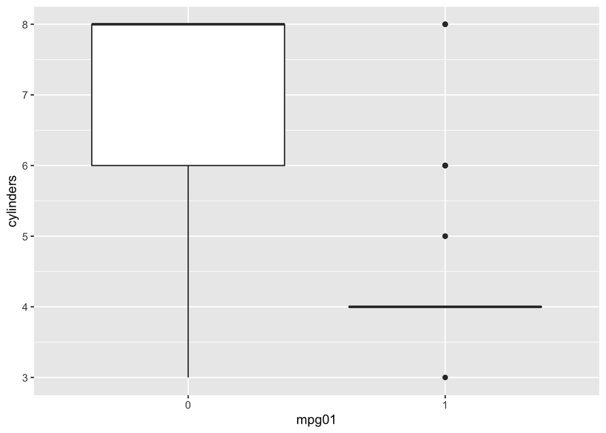

```r
#Boxplots
ggplot(Auto, aes(mpg01,cylinders)) + geom_boxplot()
```

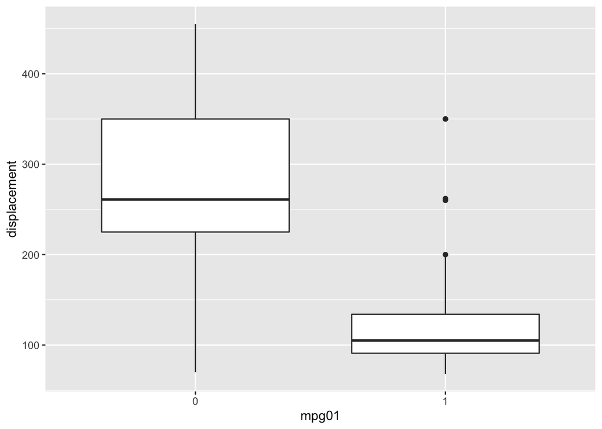

```r
ggplot(Auto, aes(mpg01,displacement)) + geom_boxplot()
```

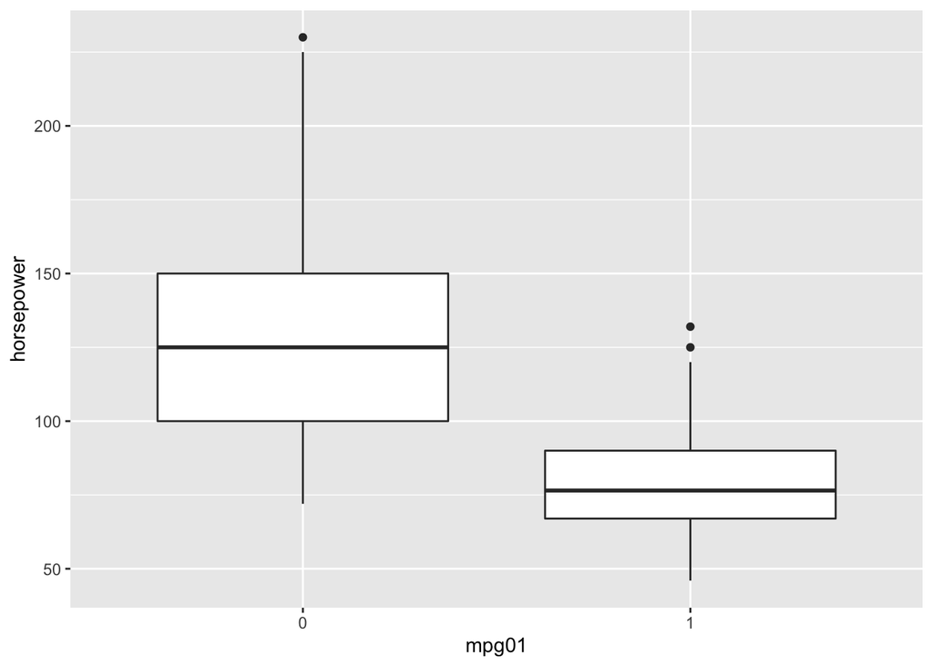

```r
ggplot(Auto, aes(mpg01,horsepower)) + geom_boxplot()
```

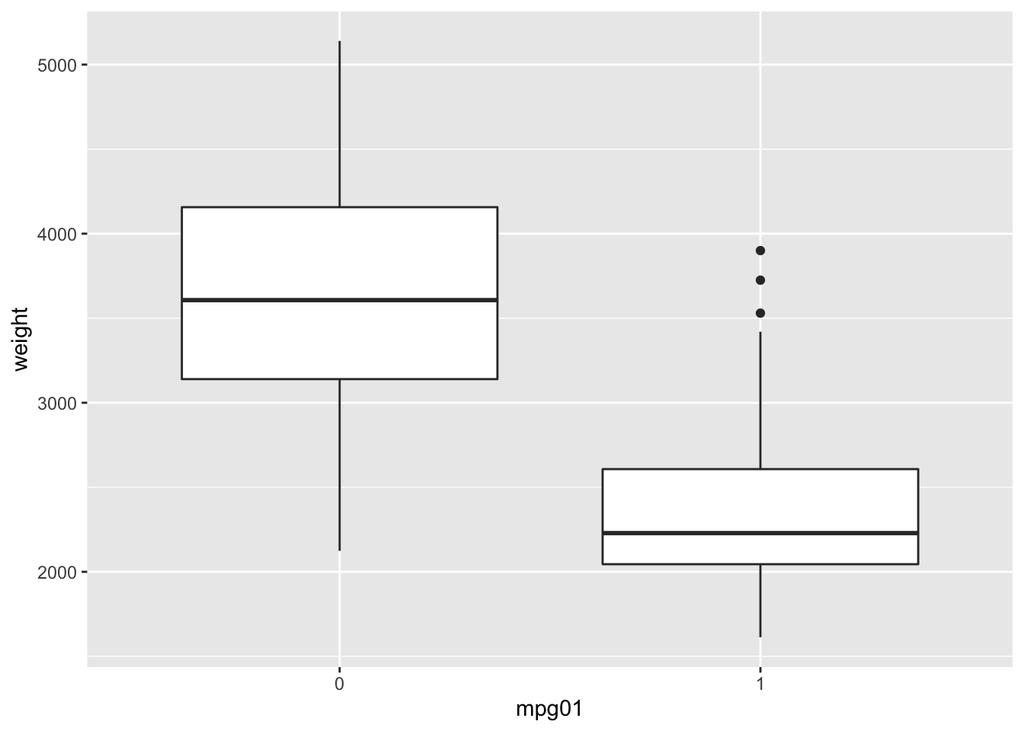

[output not shown]

```r
ggplot(Auto, aes(mpg01,weight)) + geom_boxplot()
```

```r
#split data in to 70% traing set and 30% test set
set.seed(1)
s <- sample(nrow(Auto), floor(nrow(Auto)*0.7), replace = F)
training <- Auto[s,]
test <- Auto[-s,]
```

[output not shown]

```r
library(MASS)
```

2. (New York Times Covid-19 State Data, *35 pt*) Download the data file `covid-19-state-level-data.csv`, then answer the following questions using splines.
   1. Create subsets of the data for States New York, California, and Washington. Print out the dimension and first 6 observations of each state subset.
   2. Fit both cubic splines (using `bs`) and natural cubic splines (using `ns`) on each subset, with the number of cases as response, and the number of days since first case as predictor. Find the optimal degrees of freedom (`df`) for the basis.
   3. Generate a plot of three panels, each corresponding to one state. Each panel plots the observed data and the fitted splines (different colors for cubic spline and NCS). Compare and commment on the two types of splines.
   4. Use the fitted splines from Washington and California to predict the number of cases in New York State. Which prediction is better? Comment on why/why not the prediction is good.
   5. Now use Smoothing Spline (`smooth.spline`) to fit the California data, and predict its number of cases in the next 30 days. Plot the observed data, the fitted line, and its extrapolation in a single plot. Comment on the prediction you get.